[Dewey research project](https://davidchivers.github.io/davidchivers.co.uk/dewey/)

# Dewey: public-library inventory audit and methods

19 October 2026 | Exposure, mixing and attitudes

Dark mode

Dated snapshot, 19 October 2026. Complete authored findings, prospective protocol, pre-execution clarification, construction log and independent definition review. Adds a public-inventory continuity audit only; it does not replace original protocols, earlier results, mobility-linkage gates or the stopped investment design. Project files are snapshots, not live repository access.

# Public libraries: a usable inventory lead, not yet an access measure

19 October 2026. New empirical audit of previously acquired **public IMLS Public Libraries Survey files**, FY2017-2019. This did not inspect licensed mobility records, calculate exposure or rerun the failed investment design.

## Bottom line

The inventory is sufficiently stable to justify a **bounded historical linkage audit**, but not to proceed directly to an access regression. Of 16,603 fixed-outlet candidates present in every year, 15,864 (95.55%) pass the combined street-match, unchanged-address and 100-metre continuity screen. This is a selected subset of recorded outlets, not proof of true location, continuous operation, complete opportunity coverage or a correct mobility match.

The main new obstacle is calendar alignment. Only about 37% of candidate outlets have parent reporting periods equal to the labelled calendar year. In FY2019, 677 candidates (4.03%) have parent periods with no overlap with calendar 2019. This need not be an error: reporting conventions differ. It does mean that annual service measures cannot be treated as calendar-year measures merely by joining on the survey’s year label.

**Decision: continue, narrowed.** Rank 4 stays an inventory-and-linkage task, not a demonstrated economic mechanism or an investment-event design. The next useful step requires dated mobility-side place metadata and separate authorization for local linkage. It should be chosen without inspecting exposure outcomes. The earlier investment sample-size stop remains in force.

## What was actually checked

The same three hash-verified archives used in the earlier source check were read locally without modification. Outlet identifiers were linked to their administrative-entity parent using a validated many-to-one join. There are no duplicate/malformed outlet keys, unmatched parents or parent-state conflicts in the inspected releases. The previous counts and 17,267 persistent keys are reproduced exactly.

The inherited candidate screen is central or branch type, not coded closed or temporarily closed, with finite nonzero coordinates in valid ranges. It is intentionally not a verified operating-status screen. All published geography, including territories, is retained; the full tables separately show 50-state/DC candidate counts. All reported percentages below have the stated inventory denominator, not visits, population or mobility coverage.

For address comparison, text is normalized for Unicode, case, punctuation and whitespace only. Street abbreviations and unit numbers are not removed or expanded. Street, city, state and ZIP5 must be complete. Coordinates are compared using great-circle distance across **all three year pairs**. Missing addresses do not count as identical; changes are not automatically called moves.

## Locations: stable in aggregate, but not interchangeable with IDs

| Successive screen | Outlet keys | Share of 16,603 all-year candidates |
| --- | --- | --- |
| Candidate in every year | 16,603 | 100.00% |
| Street-match code in every year | 16,220 | 97.69% |
| Plus complete normalized address unchanged | 15,867 | 95.57% |
| Plus maximum coordinate span at most 100 metres | 15,864 | 95.55% |

The 100-metre rule is a declared sensitivity screen, not an accuracy guarantee. Keeping the other thresholds, 13,671 pass at 25 metres, 15,866 at 250 metres and 15,867 at 1 kilometre. A tight 25-metre rule discards many more otherwise stable records; choosing that rule after looking at exposure would select the analysis sample for the wrong reason.

Among all 16,603 candidates, the 2017-2019 comparison has 405 normalized address differences and 504 coordinate differences above 100 metres. Of the 212 coordinate differences exceeding 1 kilometre, 120 retain the same normalized address. The largest recorded coordinate separation is about 1,402 kilometres. These are flags requiring validation, not verified relocations or evidence identifying which year’s coordinate is correct. Every adjacent and endpoint comparison is retained in the full tables.

The actual files contain GEOMATCH `A`, `9` and `5`. The released-file layouts describe A as a street-address match by interpolation; 9 and 5 are postcode centroids, not building points. The FY2017 guide’s narrative uses a different code scheme, so the audit preserves that documentation conflict rather than silently translating codes. Candidate centroid-coded records fall from 371 in 2017 to 93 in 2019. This is recorded geocoding support, not independent validation of every coordinate. [IMLS FY2017 guide, archived primary copy](https://librarydataarchive.com/USGOV/PublicLibs/Documentation/fy2017_pls_data_file_documentation.pdf).

## Dates and service measures need separate treatment

| Survey label | Candidate outlets | Parent period equals calendar year | No calendar overlap | Invalid parent period |
| --- | --- | --- | --- | --- |
| FY2017 | 16,735 | 6,229 | 677 | 0 |
| FY2018 | 16,801 | 6,229 | 675 | 4 |
| FY2019 | 16,812 | 6,228 | 677 | 0 |

Most remaining periods partially overlap the calendar year. In 2018, one reversed administrative-entity period affects four candidate outlets. It is retained as invalid, not repaired or given another parent’s dates. These are **system reporting dates**, not branch opening/closing dates or the days observed in the foot-traffic data. Even exact calendar alignment cannot establish that an outlet was open every day.

Operating variables also have explicit qualifications. In FY2019, 133 candidate outlets have missing annual service hours and 124 have missing weeks-open values. The supplied flags mark 181 hours values and 139 weeks values as carried forward from an earlier year. FY2017/2018 lack the same flag columns, which is not evidence of zero imputation. Positive hours are not proof of time-specific availability to a particular visitor. [IMLS FY2019 guide, archived primary copy](https://librarydataarchive.com/USGOV/PublicLibs/Documentation/2019_pls_data_file_documentation.pdf).

## What to do next, and what not to infer

Use this inventory only as a candidate independent list. Before joining it to mobility, specify a bounded geography and service definition, retain unmatched and ambiguous institutions, check parent/branch duplication, validate a blinded sample of address matches and reconcile historical dates. Keep centroid-coded and changing-address cases visible rather than declaring them unavailable. Current final POI schema checks do not establish precise venue coordinates or an address-based historical bridge.

Then distinguish existence, operating availability, physical reachability, observed visits and crowd composition. The 95.55% retention rate measures none of the latter four. Neither matching most institution counts nor choosing a clean stable subset establishes coverage of opportunity weight or visits. Capacity, public eligibility, travel modes and opening hours remain separate constraints. This audit therefore does not estimate segregation, access preferences, interaction, attitudes or a causal effect of library provision.

## Verification and source limits

The independent definition/code review and main rerun pass 39 synthetic tests and 75 subtests. An initial reporting-contract failure was repaired before empirical execution; its failure receipt is retained. Two fresh executions of the public audit take 4.29 and 4.30 seconds and agree on every deterministic field. Archive hashes, sizes and modification times are unchanged; all aggregate accounting checks pass. This is repeated execution of one implementation, not two independent empirical implementations.

The definition review inspected selected pages of IMLS-authored historical guides hosted by Library Data Archive, plus the packaged public READMEs. Live-original retrieval failed, so those PDF copies are not claimed to match the inaccessible originals byte-for-byte. The sourcebook records page ranges, hashes, code, construction and complete-versus-excerpt scope. No institution records or licensed data are published here.

# Public-library inventory continuity audit

19 October 2026. Written before the new address, coordinate and reporting-date comparisons. Earlier archive counts and stable-key totals are already known. This is an outcome-blind source audit, not preregistration, a mobility linkage or a restart of the failed library-investment design.

## Question and scope

Can the already acquired FY2017-2019 IMLS Public Libraries Survey public-use outlet files provide a sufficiently dated and geographically precise supply inventory for a later bounded opportunity analysis? Persistent identifiers alone do not establish unchanged premises, continued operation or access.

Use only the three existing public CSV archives and their acquisition manifest. Read outlet records and the administrative-entity (AE) keys/reporting dates locally. No Dewey, SafeGraph, Advan, ACS, employee or attitude records; no downloads, address geocoding requests or contemporary place substitution. Original archives stay read-only. Working institution-level comparisons stay outside the repository; the shared output contains national aggregates only.

## Fixed comparisons

- Reconcile archive/member hashes and prior annual row counts and persistent outlet-key totals. Require unique nonmissing outlet keys and AE keys.
- Retain the previous candidate definition: central/branch type, not coded closed/temporarily closed, and finite nonzero coordinates in valid ranges. Report all published geography and 50-state/DC counts separately. This candidate screen is not proof that the place was open to a given visitor.
- On all common keys and on candidates in all three years, report separate address/name/type/status and recorded-coordinate changes for 2017-2018, 2018-2019 and 2017-2019. Do not select the most stable pair.
- Normalize text conservatively: Unicode normalization, uppercase, punctuation removal and whitespace collapse. Do not fuzzy-match, replace street words, drop unit numbers or infer equality from two missing values. A full address is comparable only when street, city, state and five-digit ZIP are present.
- Compute great-circle distances between valid recorded coordinates. Retain thresholds 25, 100, 250 and 1,000 metres and distance quantiles. These are sensitivity screens, not error tolerances that establish true relocation. An address difference can be clerical; a coordinate change can be geocoding.
- Verify GEOMATCH, address/structure status, outlet types and operating-field flags against the historical provider definitions before interpreting codes. Preserve every observed code and unknown/missing count; absence of a flag column is not zero imputation. Do not silently treat ZIP/city centroids as accurate building coordinates. Record the definition check separately.
- Match outlet-to-AE by the documented parent key with many-to-one validation. Report unmatched and state-discordant parents. Do not borrow dates across a failed match. Parse documented dates, retain invalid/reversed/missing periods, and report exact calendar-year agreement and the share of calendar days overlapped by the AE reporting period. These are system reporting periods, not dates that every outlet operated or the dates of mobility visits.
- Show a fixed candidate continuity waterfall: all-three-year candidate keys; documented precise-geocode support in every year; complete normalized address unchanged in every year; coordinate span no more than 100 metres across any of the three pairs. Keep the other distance thresholds visible. The last set is a conservative linkage-candidate subset, not a corrected national sample or a licence to exclude difficult cases from a future paper.

## Verification and decision

Test normalization, missing-value handling, haversine distances, inclusive calendar/leap-year overlap, duplicate and failed parent joins, code handling, and stable-sample denominators on artificial inputs. A separate reviewer checks primary definitions and the implementation before empirical release. Reconcile source fingerprints and known totals; preserve all failures rather than changing filters after inspecting exposure outcomes (none are opened).

The decision is whether to continue to a separately authorized historical mobility-linkage audit, narrow to address-supported subsets, or stop for a specified source defect. Do not claim an independent feasible menu merely from passing record checks. Capacity, usable hours, travel feasibility and observed visitation remain distinct unverified requirements. This audit cannot identify causal access effects, integration, preferences or an investment event.

# Pre-execution definition clarifications

19 October 2026. Added after the independent provider-definition review and before the new empirical address, coordinate and reporting-date results were computed. The original continuity protocol remains unchanged.

The historical released-file layouts define GEOMATCH `A` as a street-address match by interpolation, `9` as a ZIP+4 centroid and `5` as a ZIP5 centroid. Use literal `A` only for the proposed precise-code screen. Call this **street-match support**, not verified building coordinates. The FY2017 narrative table uses a different coding scheme; retain literal observed codes and document that conflict rather than translating it without release evidence.

The source fields define a six-character parent key and three-character outlet suffix. Reject malformed lengths, non-ASCII-alphanumeric components, missing or duplicate keys. This is an explicit conservative format check; it does not assume the parent embeds a verified state or infer identifier continuity from names. Retain leading zeros. An encountered unrecognized format should stop execution for review, not silently drop records.

Positive infinity is not valid operating service. Count infinite values separately from finite positive values, finite negative codes and nonnumeric missing values. This is defensive input handling, not a claim that the empirical archive contains infinity. Available flag frequencies stay visible; unavailable flag columns stay null.

Add pairwise counts of keys present in both releases, only the earlier release or only the later release for all three year pairs. These diagnose record continuity; they do not measure business openings or closures. They complement, not replace, the prespecified all-three-year comparisons.

The independent synthetic suite demonstrated that later status marginals alone discard earlier status differences. Before empirical execution, add earlier/later address and structure status transitions and cross-tab recorded address-status pairs against address/coordinate comparisons. These are national record-code diagnostics, not independently verified event histories.

The independent definition ledger records archived primary-document access, selected-page inspection and live-original access failures. Source copies are not claimed to be hash-verified against the inaccessible current originals. No mobility records, exposure outcomes, original archives or earlier results are modified by these clarifications.

# Construction log: public-library inventory continuity

19 October 2026. Empirical source audit only. Canonical state is in STATUS; delivery is evidenced separately by this milestone’s receipt, not by this log.

## Inputs and authority

This work advances note 92 rank 4 under the active ranked-research goal. It uses already acquired public IMLS Public Libraries Survey public-use CSV archives for FY2017, FY2018 and FY2019, not restricted Dewey data. No new dataset acquisition, remote geocoding, mobility join or coauthor message. The local public root is supplied by the operator as `$public`; its path is not embedded in public code or this sourcebook.

Exact files below that root: `raw/archives/imls_pls_2017_csv.zip`, `imls_pls_2018_csv.zip`, `imls_pls_2019_csv.zip`, and `metadata/imls_source_manifest.csv`. Outlet and administrative-entity CSV members are selected only when a unique corresponding member exists. Data are parsed in memory as cp1252 strings, preserving leading zeros; individual institution rows, identifiers and addresses are never printed or written. The public output JSON records archive/member hashes, sizes and timestamps.

The earlier safe baseline is `output/ranked_research_20261019/public_library_readiness.json`. Its source manifest hash is `3ad45bea610590e84f2df1c763655ccf4daf3281c94bd03e2bd1bcd51e2f86a2`. Prior annual rows, candidate counts and all-three-year key count must match. All source archives pass CRC and manifest-hash checks; size, modification time and SHA-256 are checked again after execution.

## Sequence and exact transformations

1. Wrote `docs/protocols/library_inventory_continuity_20261019.md` before new address, coordinate and reporting-period results were seen. Existing totals were already known. This is not registration with an external registry.
2. An independent same-model reviewer checked selected historical definitions and wrote `workstreams/library_inventory_definition_review_20261019.md`. Live-original access failed; archived primary PDF copies and packaged READMEs supplied the bounded definition evidence. The coordinator, not the human user, selected literal GEOMATCH A based on that review.
3. Recorded pre-execution clarifications in `docs/protocols/library_inventory_definition_addendum_20261019.md`: exact key-length checks, finite service handling, pairwise key-presence accounting and preservation of both years’ status codes. The initial protocol and historical results were not overwritten.
4. `audit_library_inventory_continuity.py` validates nonmissing unique six-character parent and three-character outlet components, allowing ASCII alphanumerics without assuming a state-plus-digits scheme. It rejects malformed keys instead of silently dropping them. Parent merge is left, many-to-one on FSCSKEY; missing or state-discordant parents supply no dates.
5. Candidate rule: CE/BR, STATSTRU not 03/23, finite nonzero in-range coordinates, retaining the old sentinel convention. It is not independent proof of activity or coordinate truth. Report all geography and US50/DC counts explicitly. Keep every observed status/geocode/flag frequency.
6. Address rule: NFKC, uppercase, punctuation-to-space and whitespace collapse; retain street words and unit numbers. Require street/city/state/ZIP5; ZIP+4 is reduced to ZIP5. Missing components never form an equal address. Names are compared separately and never used as a join key.
7. For all persistent keys and all-year candidates, compare all three year pairs. Great-circle distance uses radius 6,371,008.8 metres. Retain four thresholds and quantiles, address-by-distance counts, status transitions and pairwise key presence. None is labelled a verified physical event.
8. Continuity waterfall: candidate in all years, literal A in all years, complete address identical in all years, then maximum of all three coordinate distances at most 25/100/250/1,000 metres. No outcome enters the rule. This is a selected linkage-candidate subset, not a corrected menu.
9. Parse AE dates using `%m/%d/%Y`. Overlap is the inclusive day intersection with January 1 to December 31, divided by calendar days in that year. Missing/reversed periods remain unknown, not zero overlap. Report both system and candidate-outlet denominators. These are reporting dates only.
10. HOURS and WKS_OPEN retain finite positive, zero, negative codes, nonnumeric and infinite values separately. Supplied flag counts are retained; absent FY2017/2018 flag columns are null, never zero imputation.

## Tests, failure and reproducibility

An independent artificial-input suite initially exposed a status-history reporting omission: later marginals alone discarded the earlier code. Main fixed the reporting output before empirical execution and preserved the initial failure in the definition ledger. No empirical source was repaired. Final independent and main runs pass 39 tests and 75 subtests with no skips. Tests cover keys, parents, missing addresses, documented codes, finite values, geometry, inclusive/leap-year dates, empty support, all-pair distances, non-survivor key counts and exclusion of institution fields from aggregate output.

The empirical script’s reviewed SHA-256 is `79b0a0f125b6ea9f6e1626c17c194e469c4c4e12d6478499bfaa87567833d048`. The first run takes 4.29395 seconds, the separate repeat 4.2978 seconds. `reconcile_library_inventory_audit.py` verifies all deterministic JSON fields are identical after excluding only UTC timestamp and elapsed seconds. It also checks exhaustive calendar/service/address categories, key-presence identities, status cross-tab sums and monotone distance/waterfall counts. This checks repeatability of one implementation, not an independent second estimator.

Output root: `output/library_inventory_continuity_20261019/`. Primary aggregate `public_results.json` SHA-256: `8278a12cba5f16a0d3cb267a055175c15da0c3410d8fbf86bb5b9031c2e9fc94`. Repeat output and `reproduction_receipt.json` are preserved separately. The independent aggregate review binds approval to this exact primary hash. Graph builder emits three PNGs, all six comparisons, four distance thresholds and full JSON download. Sourcebook builder checks review and figure hashes, retains complete-versus-excerpt labels and source provenance. Publication and Project upload require their own verified receipts; preparing files is not delivery.

## Reproduction commands

Verified runtime: Python 3.12.10, NumPy 2.3.5, pandas 3.0.0 and Matplotlib 3.10.8. No packages were installed or updated for this audit.

From the project directory, with `$python`, `$public` and `$pandoc` set to the installed runtime, existing public input root and Pandoc executable:

```powershell
& $python -m pytest code/analysis/test_library_inventory_continuity.py -q
& $python code/analysis/audit_library_inventory_continuity.py --public-root $public --prior-readiness output/ranked_research_20261019/public_library_readiness.json --precise-codes A --definition-review workstreams/library_inventory_definition_review_20261019.md --output output/library_inventory_replication/public_results.json
```

The audit refuses to overwrite an output. A replication folder is therefore required for later reruns. Do not overwrite delivered snapshots or change the archival input manifest. Figure, reconciliation and packet scripts expose their exact arguments through `--help`; documentation_manifest and publication manifest record the generated artifacts, source identities and public routes.

## Residual limitations

Period nonoverlap is not proof of error; one reversed FY2018 AE period is retained as invalid and affects four candidate outlets. Large coordinate changes are not verified moves. Neither a stable address nor GEOMATCH A validates a physical premises or activity throughout the year. An outlet’s public status/eligibility, dated capacity, historical travel feasibility and mobility correspondence remain unverified. No source was substituted and none of the original exposure, employee-proxy, geography or inference gates was relaxed. The failed library-investment design remains stopped.

# Public-library inventory definition review

19 October 2026. Independent, bounded sidecar to note 92 rank 4. This is not a restart of the failed investment-event design or a verified mobility link. Only this note and `code/analysis/test_library_inventory_continuity.py` are owned here. No empirical archive rows, restricted inputs, Dropbox scans, messages or publication were used. Main’s empirical run was still unstarted when the definition ledger below was assembled.

## Sources and inspection limits

The live [PLS landing page](https://www.imls.gov/research-evaluation/surveys/public-libraries-survey-pls) and all three official documentation URLs returned HTTP 403 through web retrieval; a direct FY2017 request timed out. Official indexed text supplied FY2017 C-1/C-3. IMLS-authored PDF copies were then retrieved from Library Data Archive into memory only. These are copies of primary documents, not independently verified live-original bytes. No access control was bypassed and no PDF, data extract or rendering was saved to disk.

| Vintage | Official primary document | Copy actually inspected | Physical pages / SHA-256 |
| --- | --- | --- | --- |
| FY2017, May 2019 | [IMLS guide](https://www.imls.gov/sites/default/files/fy2017_pls_data_file_documentation.pdf) | [Archived IMLS PDF](https://librarydataarchive.com/USGOV/PublicLibs/Documentation/fy2017_pls_data_file_documentation.pdf) | 163 / `ed96c868deddaf0af0ad2ad04cc215fec5f47f523acac2266f5cca9d401d4d37` |
| FY2018, July 2020 | [IMLS guide](https://www.imls.gov/sites/default/files/2018_pls_data_file_documentation.pdf) | [Archived IMLS PDF](https://librarydataarchive.com/USGOV/PublicLibs/Documentation/2018_pls_data_file_documentation.pdf) | 169 / `5e15d774149319907d30e767bb8913bae8fd80321028814bdcd6857d59d876fb` |
| FY2019, May 2021 | [IMLS guide](https://www.imls.gov/sites/default/files/2021-05/2019_pls_data_file_documentation.pdf) | [Archived IMLS PDF](https://librarydataarchive.com/USGOV/PublicLibs/Documentation/2019_pls_data_file_documentation.pdf) | 166 / `8c00df3dba8069daab7006f8a3014bc13e2de991c168f85eeec59ebeb61d3b47` |

An in-memory PyMuPDF 1.27.1 census accounted for every page; all PDFs were unencrypted. This was a **selected-definition review, not whole-PDF reading**. Web screenshots did not expose usable pixels here; direct in-memory rendering did. Visually checked physical pages: FY2017 29-30, 38, 63-65, 69, 86-87, 101-103, 105; FY2018 31-32, 40, 66-68, 89-90, 105-106, 108; FY2019 27, 31-32, 39, 63-65, 85-86, 101-102, 104. Other referenced questionnaire passages were checked in native page-marked text. No whole-document visual census or OCR certification is claimed. Printed page labels below were mapped within the inspected sections, not inferred from one universal offset.

Public README text was read in memory from exactly the three named existing ZIPs. Members: `PLS_FY2017_Data_Files_CSV/README FY17 PLS PUD.txt`, `README FY 2018 PLS PUD.txt`, `README FY 2019 PLS PUD.txt`. Relevant sections are **Description of files**, **Public-use data files and programs**, and **Appendix A: Recoding negative values**, specifically the outlet block. The existing `output/ranked_research_20261019/public_library_readiness.json` was read as a prior aggregate, not recomputed.

## Definition ledger

`STOP_*` and `CAUTION_*` below are this review’s recommendations, not IMLS codes or changes to main’s frozen protocol. Stops apply to the affected claim or record, not automatically to the entire descriptive inventory audit.

[output not shown]

Two additional documentation cautions: FY17 questionnaire item 709 still prints `BM` for mail service although its released-file C-2 explicitly says `MO` replaced BM before these years (`CAUTION_STALE_QUESTIONNAIRE_CODE`). FY18 C-1, PDF p. 66, prints 17,452 records/37 fields, whereas that release’s README and safe prior aggregate give 17,478/36 (`CAUTION_HEADER_CONFLICT`). Use release headers/hashes and explicit reconciliation, not either stale header as an automatic sample target. Do not modify the historical results.

## Focused test recommendations

1. Preserve three-digit suffixes, reject duplicate/missing/malformed keys and duplicate AE parents, and never match on names or coordinates.
2. Keep conservative punctuation/Unicode normalization without dropping units, expanding street abbreviations or treating two missing addresses as equal.
3. Separate 03/23 from 04/11 and STATADDR 07/15. Keep literal A/9/5, alternative FY17 encodings and unknown values visible; centroid coordinates must not enter the A-only continuity waterfall.
4. Test identical, known-distance and antipodal haversine pairs; reject NaN, infinity, sentinels and out-of-range coordinates before comparisons.
5. Test inclusive single-day, partial fiscal, disjoint, leap-year, multi-year, invalid and reversed date ranges. Orphan/disagreeing parents yield no dates. Assert calendar-category counts partition their stated denominators.
6. Use a synthetic panel with entrants, exits, temporary closures, restorations, address-only and coordinate-only differences. Reconcile every transition, including keys absent in one year, rather than showing only survivors.
7. Retain absent versus present service flags and negative/zero/positive service separately. Positive infinity is not valid operating service. Retain all prespecified distance thresholds and prohibit row/identifier exports.

## Module review and execution

Main module exists. The coordinating agent selected literal A-only screening based on this definition review; this was not a direct human instruction. Main adopted six-/three-character ASCII alphanumeric key validation, without assuming a state-plus-digits pattern. Keys and positive-service/nonfinite handling were hardened by main, not this sidecar, before empirical inspection. Main also added pairwise key-presence counts explicitly not labelled openings/closures.

First synthetic run: `python -B -m unittest -v test_library_inventory_continuity` from `code/analysis`; 36 tests, 35 passed, one test with two failing subcases (3.681 seconds). Tested main hash after that run: `522beb5518a80be518cab6cd1327f26f896fb42f1135cf7aae54d24471b76181`.

**Initial defect receipt, P2 (now resolved):** `compare()` returned only later-year `STATSTRU/STATADDR` marginals. Two synthetic histories with different earlier codes produced identical comparison output, so recorded-status transitions could not be recovered despite retained annual totals. The recommendation was to retain both marginals and paired code counts, including missing/unknown states, reconciling to `common_keys`. This was a reporting-contract defect, not evidence of misreported real libraries or physical moves. The regression test was an ordinary failing test, not skipped or marked expected.

After adding the requested key-presence and nonfinite-service cases, the pre-fix run contained 39 tests: 38 passed and the same one test had two failing subcases (4.206 seconds). These failure receipts are retained rather than overwritten by the successful rerun.

**Resolution reviewed:** main now retains earlier and later status marginals, structure/address transition tables, and address-status-pair cross-tabs with observed address categories and distance bins. Read-only code inspection and the unchanged regression test confirm that earlier status history is no longer discarded. Final reviewed main SHA-256: `79b0a0f125b6ea9f6e1626c17c194e469c4c4e12d6478499bfaa87567833d048`.

Final independent synthetic rerun: **39 tests and 75 subtests passed**, zero failures, errors or skips (5.764 seconds). The same suite was loaded with `python -B` and a counting `unittest.TextTestResult`; no tests were added during close-out. The preceding ordinary `python -B -m unittest -v test_library_inventory_continuity` run also passed all 39 tests (5.760 seconds). Coverage includes documented-length key validation, pairwise presence including nonsurvivors, closure without key disappearance, both signs of infinite service, literal GEOMATCH handling, and inclusive AE/calendar overlap.

No remaining defect was identified within this bounded review. Synthetic success does not validate empirical inputs, physical moves or mobility linkage; the FY17 GEOMATCH documentation conflict and all source-access limits remain. No main-module edits or empirical execution were performed by this sidecar. The public-archive run remained unstarted at handoff, per the coordinator.

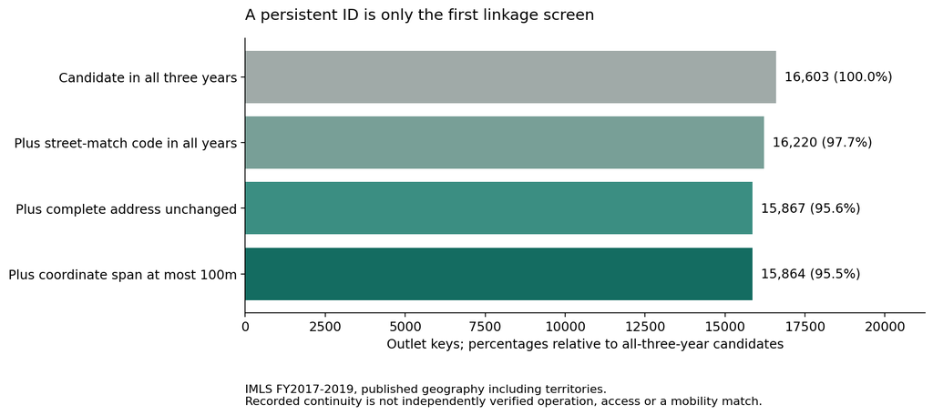

Continuity screens for the same outlet keys

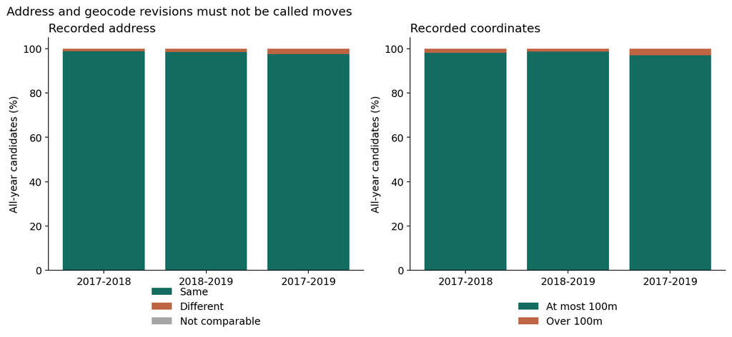

Recorded address and coordinate differences in every year pair

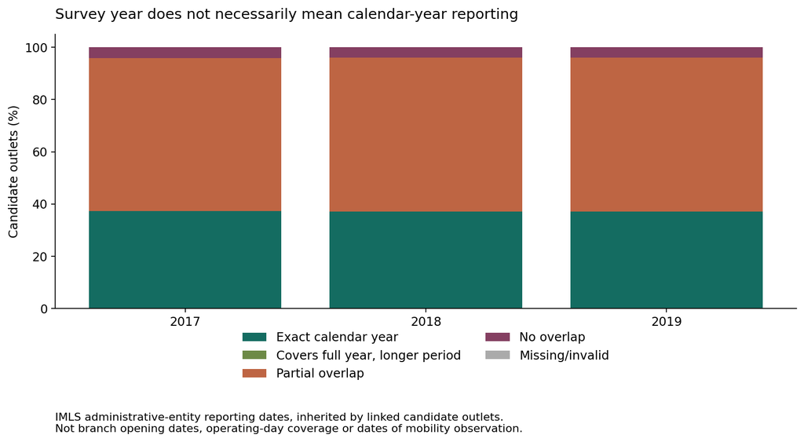

Parent reporting periods versus calendar years

# Complete national inventory checks

All published geography, including territories, unless explicitly labelled US50/DC. Street-match support is GEOMATCH A, not independent building-coordinate validation.

## Annual support

| FY | All outlets | Candidates | US50/DC candidates | Street-match candidates | Complete address |
| --- | --- | --- | --- | --- | --- |
| 2017 | 17,452 | 16,735 | 16,724 | 16,364 | 16,735 |
| 2018 | 17,478 | 16,801 | 16,786 | 16,673 | 16,801 |
| 2019 | 17,496 | 16,812 | 16,796 | 16,719 | 16,812 |

## Key presence, not openings or closures

| Years | Both releases | Earlier only | Later only | Union |
| --- | --- | --- | --- | --- |
| 2017-2018 | 17,348 | 104 | 130 | 17,582 |
| 2018-2019 | 17,396 | 82 | 100 | 17,578 |
| 2017-2019 | 17,270 | 182 | 226 | 17,678 |

## Every pair and both samples

| Years | Sample | Keys | Same address | Different address | Unusable address | Coordinates >100m | Coordinates >1km |
| --- | --- | --- | --- | --- | --- | --- | --- |
| 2017-2018 | all three year keys | 17,267 | 17,059 | 208 | 0 | 353 | 157 |
| 2017-2018 | candidate in all three | 16,603 | 16,411 | 192 | 0 | 323 | 139 |
| 2018-2019 | all three year keys | 17,267 | 17,013 | 254 | 0 | 231 | 105 |
| 2018-2019 | candidate in all three | 16,603 | 16,363 | 240 | 0 | 216 | 93 |
| 2017-2019 | all three year keys | 17,267 | 16,833 | 434 | 0 | 547 | 240 |
| 2017-2019 | candidate in all three | 16,603 | 16,198 | 405 | 0 | 504 | 212 |

## Full distance sensitivity

| Sample / years | >25m | >100m | >250m | >1km | Median metres | 99th percentile metres |
| --- | --- | --- | --- | --- | --- | --- |
| all three year keys / 2017-2018 | 2,763 | 353 | 289 | 157 | 5.4 | 845.2 |
| candidate in all three / 2017-2018 | 2,627 | 323 | 263 | 139 | 5.4 | 758.9 |
| all three year keys / 2018-2019 | 269 | 231 | 186 | 105 | 0.0 | 309.7 |
| candidate in all three / 2018-2019 | 253 | 216 | 171 | 93 | 0.0 | 277.8 |
| all three year keys / 2017-2019 | 2,963 | 547 | 439 | 240 | 5.4 | 1696.7 |
| candidate in all three / 2017-2019 | 2,812 | 504 | 400 | 212 | 5.4 | 1493.5 |

## Selected continuity subset: all thresholds

| Maximum span across all three pairs | Outlet keys | Share of initial all-year candidates |
| --- | --- | --- |
| At most 25m | 13,671 | 82.34% |
| At most 100m | 15,864 | 95.55% |
| At most 250m | 15,866 | 95.56% |
| At most 1000m | 15,867 | 95.57% |

## Reporting-calendar alignment

| FY | Unit | Rows | Exact calendar | Partial overlap | No overlap | Missing/invalid | Mean overlap, valid |
| --- | --- | --- | --- | --- | --- | --- | --- |
| 2017 | all systems | 9,245 | 3,645 | 5,271 | 300 | 29 | 70.26% |
| 2017 | candidate outlets | 16,735 | 6,229 | 9,829 | 677 | 0 | 69.16% |
| 2018 | all systems | 9,261 | 3,638 | 5,311 | 299 | 13 | 70.18% |
| 2018 | candidate outlets | 16,801 | 6,229 | 9,893 | 675 | 4 | 69.11% |
| 2019 | all systems | 9,260 | 3,631 | 5,308 | 302 | 19 | 70.14% |
| 2019 | candidate outlets | 16,812 | 6,228 | 9,907 | 677 | 0 | 69.09% |

The complete JSON retains all observed code frequencies, missing/negative operating-field codes, available imputation flags, parent-join checks, address-by-distance cross-tabs, distance quantiles and source hashes. Absent flag columns are null, not zero imputation. These are public-inventory diagnostics, not exposure estimates.

## Source identity and supersession

- `notes/95_library_inventory_continuity.md`: Complete findings, decision and interpretation; SHA-256 `88b64fb4bdf61c3808343976e0b4aad675ce25fdaa171fe277c6d183cb28997c`.
- `docs/protocols/library_inventory_continuity_20261019.md`: Complete prospective source-audit protocol; SHA-256 `e549bff077aa26ff79c3679bc031001ab04c219aa083a8f8e589ab8d4ed29eb6`.
- `docs/protocols/library_inventory_definition_addendum_20261019.md`: Complete pre-execution definition clarification; SHA-256 `d8bade36ea29c400009ecea435abeda93ac51df7c7ff9d8cbc88de20e59148cf`.
- `docs/data_construction/95_library_inventory_continuity.md`: Complete construction log; delivery recorded separately; SHA-256 `b954a772106da84b9467f448d462a6401aa4421cc9bc0b52edd4fc33b39d26f8`.
- `workstreams/library_inventory_definition_review_20261019.md`: Complete independent selected-definition and synthetic-test review; SHA-256 `eb97498a20594232d17d8fb7e8581c43f95eea1738247275b26bb966fea2c749`.
- `output/library_inventory_continuity_20261019/public_results.json`: Complete national public-inventory diagnostic; no institution records; SHA-256 `8278a12cba5f16a0d3cb267a055175c15da0c3410d8fbf86bb5b9031c2e9fc94`.
- `output/library_inventory_continuity_20261019/complete_tables.md`: Complete national public-inventory diagnostic; no institution records; SHA-256 `9e3709727390a388e640b5e90f3a7d63b1d7553e4fc11d7c1455c9969f69871a`.
- `output/library_inventory_continuity_20261019/library_continuity.png`: Complete national public-inventory diagnostic; no institution records; SHA-256 `83a580b22798b2697cf6a4c1472ab24427c88788852bab0665b9fcc882524d0f`.
- `output/library_inventory_continuity_20261019/library_recorded_changes.png`: Complete national public-inventory diagnostic; no institution records; SHA-256 `8faf8fbf6ac3698e3928c67bc2d97ef6a12d00f9b3d7c5ebd7e06c8df7e23b0f`.
- `output/library_inventory_continuity_20261019/library_reporting_calendar.png`: Complete national public-inventory diagnostic; no institution records; SHA-256 `36bc0e6053c81dafb95aa71b691ed04b6437a57d21909d16d7c8ae43bcd6cb85`.
- `output/library_inventory_continuity_20261019/independent_review.json`: Verification receipt fingerprint; not embedded in full; SHA-256 `8a731740086059f2471f5db3935c18f9d658e7c4c361b783322529567766d3df`.
- `output/library_inventory_continuity_20261019/reproduction_receipt.json`: Verification receipt fingerprint; not embedded in full; SHA-256 `6a2fe527eee8b85f2dedbd20e7f8bca66dfabb4ecd30dacd07cb66738048180f`.